# Practical Machine Learning Course Project

P. Fleer

28 April 2017

## Executive Summary

Using data from accelerometers on the belt, forearm, arm, and dumbell of 6 participants, this report aims at predicting the manner in which the participants executed a series of training exercises. They had to perform barbell lifts correctly and incorrectly in 5 different ways.

The data for this project come originally from the Human Activity Recognition ([HAR](http://groupware.les.inf.puc-rio.br/har)) site. But for this project the data were downloaded from a cloudfront site indicated by the assignment prescriptions (see below).

For more information see: Velloso, E.; Bulling, A.; Gellersen, H.; Ugulino, W.; Fuks, H. “Qualitative Activity Recognition of Weight Lifting Exercises. Proceedings of 4th International Conference in Cooperation with SIGCHI (Augmented Human ’13)”. Stuttgart, Germany: ACM SIGCHI, 2013 (see pdf [here](https://github.com/lgreski/datasciencectacontent/blob/master/markdown/resources/2013.Velloso.QAR-WLE.pdf)).

Concretely, the task is to estimate the outcome variable “Classe” indicating the five possible manners (classes) of execution by the prediction variables containing the accelerator measurements. The classes were defined as follows: class A: exact performance according to the specification, class B: throwing the elbows to the front, class C: lifting the dumbbell only halfway, class D: lowering the dumbbell only halfway, class E: throwing the hips to the front.

The report concludes that, out of three models, the random forest model works best to predict the quality of performing the exercises.

## Download Data

```r
gettrain <- "https://d396qusza40orc.cloudfront.net/predmachlearn/pml-training.csv"
download.file(gettrain, destfile = "./pml-training.csv")

gettest <- "https://d396qusza40orc.cloudfront.net/predmachlearn/pml-testing.csv"
download.file(gettest, destfile = "./pml-testing.csv")
```

## Loading Data Sets

```r
library(caret)
trainRaw <- read.csv("pml-training.csv", header = TRUE)
testRaw <- read.csv("pml-testing.csv", header = TRUE)
(nacount <-  length(trainRaw[, apply(is.na(trainRaw), 2, any)]))
```

```
## [1] 67
```

```r
(nzvcount <- length(nearZeroVar(trainRaw)))
```

```
## [1] 60
```

```r
#str(trainRaw)
```

A look into the data shows, that out of the 160 columns there are plenty with NAs or with values near zero variance (NZV). Moreover, str(trainRaw), which is not executed here, shows that the first 6 columns are ID variables which do not matter for the prediction exercise. We will remove these columns.

## Cleaning Training Data

```r
##Removing columns
trainset <- trainRaw[, -c(1:6)]
##Remove NZA
nzv <- nearZeroVar(trainset)
trainset <- trainset[, -nzv]
dim(trainset)
```

```
## [1] 19622    95
```

```r
#Removing mostly NA
na97    <- sapply(trainset, function(x) mean(is.na(x))) > 0.97
trainset <- trainset[, na97==FALSE]
dim(trainset)
```

```
## [1] 19622    54
```

## Partitioning Training Data

Now, after having reduced the variables to 54, we are going to create a training set proper to build the models and a validation set to establish out-of-sample error. We will apply a 80 : 20 split of training and validation samples respectively.

```r
intrain  <- createDataPartition(trainset$classe, p=0.80, list=FALSE)
train <- trainset[intrain, ]
validation  <- trainset[-intrain, ]
```

## Exploratory Analysis of Training Set

```r
#Overview over the predictor variables
sumvar <- summary(train[,1])
for(i in 2 : (ncol(train)-1)) {
    var <- summary(train[,i])
    sumvar <- rbind(sumvar, var)
}
rownames(sumvar) <- names(train[1:nrow(sumvar)])
sumvar
```

```
##                          Min.  1st Qu.   Median       Mean 3rd Qu.    Max.
## num_window               1.00  220.000  425.000  4.301e+02  643.00  864.00
## roll_belt              -28.90    1.100  114.000  6.471e+01  123.00  162.00
## pitch_belt             -55.80    1.710    5.280  1.915e-01   15.10   60.30
## yaw_belt              -180.00  -88.300  -12.200 -1.058e+01   13.80  179.00
## total_accel_belt         0.00    3.000   17.000  1.134e+01   18.00   29.00
## gyros_belt_x            -1.04   -0.050    0.030 -5.764e-03    0.11    2.22
## gyros_belt_y            -0.64    0.000    0.020  3.998e-02    0.11    0.64
## gyros_belt_z            -1.46   -0.200   -0.100 -1.306e-01   -0.02    1.62
## accel_belt_x          -120.00  -21.000  -15.000 -5.429e+00   -5.00   85.00
## accel_belt_y           -69.00    3.000   36.000  3.026e+01   61.00  164.00
## accel_belt_z          -275.00 -162.000 -153.000 -7.303e+01   27.00  105.00
## magnet_belt_x          -52.00    9.000   35.000  5.602e+01   60.00  485.00
## magnet_belt_y          354.00  581.000  601.000  5.937e+02  610.00  673.00
## magnet_belt_z         -623.00 -375.000 -319.000 -3.452e+02 -306.00  293.00
## roll_arm              -180.00  -31.600    0.000  1.782e+01   77.10  180.00
## pitch_arm              -88.80  -26.100    0.000 -4.785e+00   11.10   88.50
## yaw_arm               -180.00  -42.900    0.000 -5.851e-01   45.30  180.00
## total_accel_arm          1.00   17.000   27.000  2.551e+01   33.00   65.00
## gyros_arm_x             -6.37   -1.320    0.080  4.625e-02    1.57    4.87
## gyros_arm_y             -3.44   -0.800   -0.240 -2.588e-01    0.14    2.84
## gyros_arm_z             -2.28   -0.070    0.230  2.706e-01    0.72    3.02
## accel_arm_x           -404.00 -242.000  -43.000 -5.985e+01   84.00  437.00
## accel_arm_y           -318.00  -54.000   14.000  3.216e+01  139.00  308.00
## accel_arm_z           -630.00 -144.000  -47.000 -7.098e+01   24.00  292.00
## magnet_arm_x          -584.00 -298.500  292.000  1.931e+02  637.00  782.00
## magnet_arm_y          -392.00   -8.000  200.000  1.566e+02  323.00  582.00
## magnet_arm_z          -596.00  130.000  443.000  3.062e+02  545.00  694.00
## roll_dumbbell         -153.50  -18.490   48.220  2.404e+01   67.69  153.40
## pitch_dumbbell        -149.60  -40.690  -20.900 -1.080e+01   17.44  149.40
## yaw_dumbbell          -150.90  -77.720   -4.588  1.392e+00   79.59  155.00
## total_accel_dumbbell     0.00    4.000   10.000  1.376e+01   20.00   58.00
## gyros_dumbbell_x      -204.00   -0.030    0.130  1.568e-01    0.35    2.22
## gyros_dumbbell_y        -2.10   -0.140    0.050  5.009e-02    0.21   52.00
## gyros_dumbbell_z        -2.38   -0.310   -0.130 -1.241e-01    0.03  317.00
## accel_dumbbell_x      -419.00  -51.000   -8.000 -2.884e+01   11.00  235.00
## accel_dumbbell_y      -189.00   -8.000   43.000  5.311e+01  112.00  315.00
## accel_dumbbell_z      -334.00 -142.000   -1.000 -3.870e+01   38.00  318.00
## magnet_dumbbell_x     -643.00 -536.000 -480.000 -3.288e+02 -302.50  592.00
## magnet_dumbbell_y     -742.00  231.000  310.000  2.211e+02  390.00  633.00
## magnet_dumbbell_z     -262.00  -46.000   14.000  4.551e+01   95.00  452.00
## roll_forearm          -180.00   -0.555   20.700  3.378e+01  140.00  180.00
## pitch_forearm          -72.50    0.000    9.040  1.073e+01   28.40   89.80
## yaw_forearm           -180.00  -68.450    0.000  1.910e+01  110.00  180.00
## total_accel_forearm      0.00   29.000   36.000  3.470e+01   41.00  108.00
## gyros_forearm_x        -22.00   -0.210    0.050  1.630e-01    0.58    3.97
## gyros_forearm_y         -7.02   -1.460    0.030  7.549e-02    1.61  311.00
## gyros_forearm_z         -8.09   -0.180    0.080  1.564e-01    0.49  231.00
## accel_forearm_x       -498.00 -178.000  -57.000 -6.214e+01   76.00  477.00
## accel_forearm_y       -537.00   57.000  201.000  1.642e+02  312.00  923.00
## accel_forearm_z       -410.00 -182.000  -39.000 -5.557e+01   25.00  291.00
## magnet_forearm_x     -1280.00 -616.000 -378.000 -3.132e+02  -73.00  672.00
## magnet_forearm_y      -896.00    5.000  593.000  3.808e+02  737.00 1480.00
## magnet_forearm_z      -973.00  198.000  512.000  3.961e+02  654.00 1080.00
```

The overview does not show any irregularities that would require treatments.

A correlation plot shows that there are a few highly correlated variables, but their number is limited. So we do not care about them and trust in the models that they will handle them correctly.

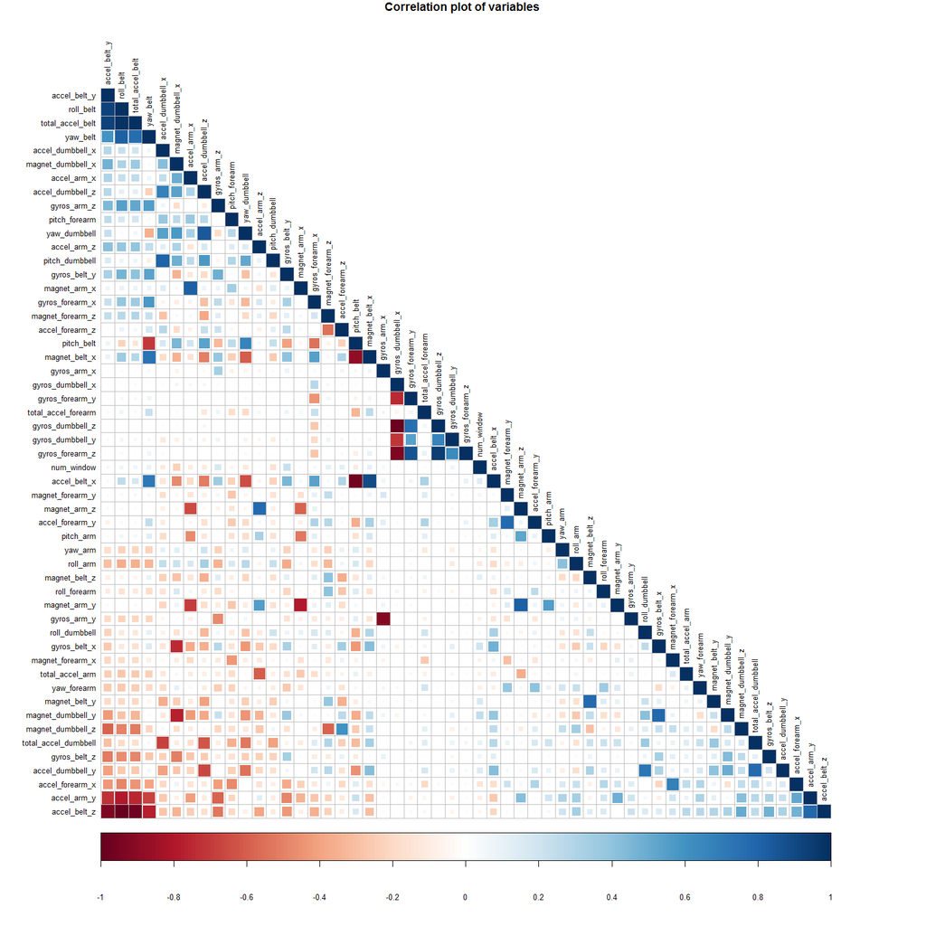

```r
library(corrplot)
corMatrix <- cor(train[, -54])
corrplot(corMatrix, order = "FPC", method = "square", type = "lower", title = "Correlation plot of variables",
         mar=c(0,0,1,0), tl.cex = 0.8, tl.col = rgb(0, 0, 0))
```

The following histogram shows that the frequencies of the outcome variable “Classe” are within reasonable margins. So we can abstain from any normalizing treatment.

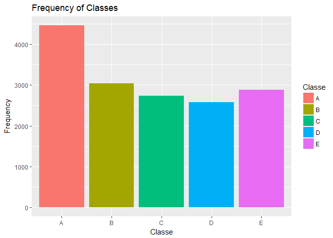

```r
library(plyr); library(ggplot2)
fcount <- count (train$classe)
names(fcount) <- c("Classe", "Frequency")
g1 <- ggplot(fcount, aes(x=Classe, y=Frequency, fill=Classe))#, fill=lang))  #, fill = "blue"))
g1 <- g1 + geom_bar(stat="identity")
g1 <- g1 + ggtitle("Frequency of Classes")
g1
```

## Building Prediction Models

We are going to build three models: Random Forest (RF), Gradient Boosting Machine (GBM) and Classification And Regression Trees (CART). That is to say, in order to shorten the knitr rendering procedure we have built and saved them beforehand. So they only have to be loaded. For reasons of transparency we show the code but do not execute it.

### Random Forest Model

```r
#Configure parallel processing
library(parallel); library(doParallel)
clust <- makeCluster(detectCores() - 1) # convention to leave 1 core for OS
registerDoParallel(clust)

#Build model
set.seed(1234)

##Configure trainControl object
ctrlrf <- trainControl(method = "cv", number = 10, allowParallel = TRUE)

##Develop training model
system.time(modrf <- train(classe ~ ., data=train, method="rf", trControl=ctrlrf))

#Save model
save(modrf, file="modelRF.RData")

##De-register parallel processing cluster
stopCluster(clust)
registerDoSEQ()
```

The most important characteristics of the model are shown below. The best accuracy was reached with a split of 27 variables. VarImp() shows the 20 most important of them.

```r
#Load model
load(file="modelRF.RData", verbose=TRUE)
```

```
## Loading objects:
##   modrf
```

```r
modrf
```

```
## Random Forest
##
## 15699 samples
##    53 predictor
##     5 classes: 'A', 'B', 'C', 'D', 'E'
##
## No pre-processing
## Resampling: Cross-Validated (10 fold)
## Summary of sample sizes: 14129, 14129, 14130, 14129, 14129, 14128, ...
## Resampling results across tuning parameters:
##
##   mtry  Accuracy   Kappa
##    2    0.9956049  0.9944403
##   27    0.9977707  0.9971800
##   53    0.9959869  0.9949233
##
## Accuracy was used to select the optimal model using  the largest value.
## The final value used for the model was mtry = 27.
```

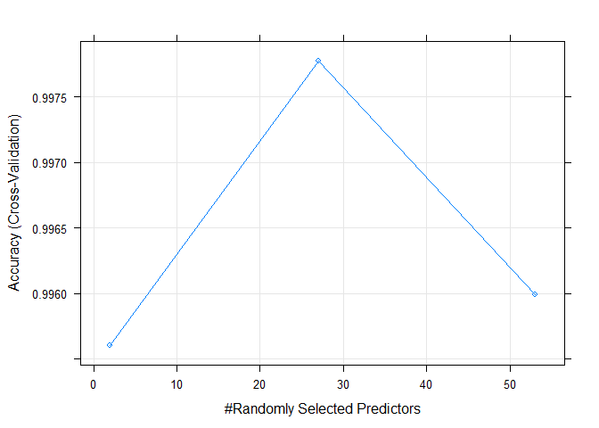

```r
plot(modrf)
```

```r
varImp(modrf)
```

```
## rf variable importance
##
##   only 20 most important variables shown (out of 53)
##
##                      Overall
## num_window           100.000
## roll_belt             62.879
## pitch_forearm         39.397
## yaw_belt              31.065
## magnet_dumbbell_z     28.763
## magnet_dumbbell_y     28.633
## pitch_belt            28.287
## roll_forearm          25.781
## accel_dumbbell_y      14.075
## magnet_dumbbell_x     10.921
## accel_forearm_x       10.874
## roll_dumbbell          9.937
## accel_belt_z           8.846
## total_accel_dumbbell   8.445
## accel_dumbbell_z       8.213
## magnet_forearm_z       7.550
## magnet_belt_z          7.116
## magnet_belt_y          7.115
## magnet_belt_x          5.468
## yaw_dumbbell           4.686
```

We have an accuracy of 0.9977707 and an in-sample error of 0.22293%.

By cross-validating with the validation set we get the out-of-sample error.

```r
#Prediction of validation set
predrfval <- predict(modrf, newdata=validation)
(cfmrfval <- confusionMatrix(predrfval, validation$classe))
```

```
## Confusion Matrix and Statistics
##
##           Reference
## Prediction    A    B    C    D    E
##          A 1116    0    0    0    0
##          B    0  759    0    0    0
##          C    0    0  684    0    0
##          D    0    0    0  643    1
##          E    0    0    0    0  720
##
## Overall Statistics
##
##                Accuracy : 0.9997
##                  95% CI : (0.9986, 1)
##     No Information Rate : 0.2845
##     P-Value [Acc > NIR] : < 2.2e-16
##
##                   Kappa : 0.9997
##  Mcnemar's Test P-Value : NA
##
## Statistics by Class:
##
##                      Class: A Class: B Class: C Class: D Class: E
## Sensitivity            1.0000   1.0000   1.0000   1.0000   0.9986
## Specificity            1.0000   1.0000   1.0000   0.9997   1.0000
## Pos Pred Value         1.0000   1.0000   1.0000   0.9984   1.0000
## Neg Pred Value         1.0000   1.0000   1.0000   1.0000   0.9997
## Prevalence             0.2845   0.1935   0.1744   0.1639   0.1838
## Detection Rate         0.2845   0.1935   0.1744   0.1639   0.1835
## Detection Prevalence   0.2845   0.1935   0.1744   0.1642   0.1835
## Balanced Accuracy      1.0000   1.0000   1.0000   0.9998   0.9993
```

That gives an accuracy of 0.9997451 or an out-of-sample error of 0.0254907%. Interestingly, the out-of-sample error seems to be slightly smaller than the in-sample error, which is not what we would expect. But both values are above the bottom line for the final prediction exercise suggested by [Leonard Greski](https://github.com/lgreski/datasciencectacontent/blob/master/markdown/pml-requiredModelAccuracy.md).

We will try GBM and CART models in order to have a basis for comparison of models. As with the RF model, we built and saved these models beforehand and only load them here; code is shown for transparency.

### GBM-Model

```r
#Configure parallel processing
library(parallel); library(doParallel)
clust <- makeCluster(detectCores() - 1) ## convention to leave 1 core for OS
registerDoParallel(clust)

#Build model
set.seed(1234)
ctrlgbm <- trainControl(allowParallel = TRUE)
system.time(modgbm <- train(classe ~ ., data=train, method="gbm", trControl=ctrlgbm))
modgbm
modgbm$finalModel
confusionMatrix.train(modgbm)

#Save model
save(modgbm, file="modelGBM.RData")

##De-register parallel processing cluster
stopCluster(clust)
registerDoSEQ()
```

```r
#Load model
load(file="modelGBM.RData", verbose=TRUE)
```

```
## Loading objects:
##   modgbm
```

At this stage, we are interested only in the out-of-sample error.

```r
##Prediction of validation set
predgbmval <- predict(modgbm, newdata=validation)
(cfmgbmval <- confusionMatrix(predgbmval, validation$classe))
```

```
## Confusion Matrix and Statistics
##
##           Reference
## Prediction    A    B    C    D    E
##          A 1115    2    0    0    0
##          B    1  753    3    0    2
##          C    0    4  680   10    1
##          D    0    0    1  632    5
##          E    0    0    0    1  713
##
## Overall Statistics
##
##                Accuracy : 0.9924
##                  95% CI : (0.9891, 0.9948)
##     No Information Rate : 0.2845
##     P-Value [Acc > NIR] : < 2.2e-16
##
##                   Kappa : 0.9903
##  Mcnemar's Test P-Value : NA
##
## Statistics by Class:
##
##                      Class: A Class: B Class: C Class: D Class: E
## Sensitivity            0.9991   0.9921   0.9942   0.9829   0.9889
## Specificity            0.9993   0.9981   0.9954   0.9982   0.9997
## Pos Pred Value         0.9982   0.9921   0.9784   0.9906   0.9986
## Neg Pred Value         0.9996   0.9981   0.9988   0.9967   0.9975
## Prevalence             0.2845   0.1935   0.1744   0.1639   0.1838
## Detection Rate         0.2842   0.1919   0.1733   0.1611   0.1817
## Detection Prevalence   0.2847   0.1935   0.1772   0.1626   0.1820
## Balanced Accuracy      0.9992   0.9951   0.9948   0.9905   0.9943
```

With accuracy of 0.9923528 and out-of-error rate of 0.7647209, this model is worse than RF. Yet, the accuracy is also above the “Greski benchmark” of at least .99.

### CART-Model

```r
#Configure parallel processing
library(parallel); library(doParallel)
clust <- makeCluster(detectCores() - 1)
registerDoParallel(clust)

#Build model
set.seed(1234)
ctrlcart <- trainControl(allowParallel = TRUE)
system.time(modcart <- train(classe ~ ., data=train, method="rpart", trControl=ctrlcart))

#Save
save(modcart, file="modelCART.RData")

##De-register parallel processing cluster
stopCluster(clust)
registerDoSEQ()
```

```r
#Load model
load(file="modelCART.RData", verbose=TRUE)
```

```
## Loading objects:
##   modcart
```

```r
modcart$result[1,2]
```

```
## [1] 0.5027284
```

At first glance, we see that this model with accuracy of 0.5027284 is out of consideration.

## Prediction on Test Set with Random Forest Model

We will use the RF model for predicting the 20 cases in the test set. No cleaning is performed with the test set.

```r
#Predict test samples
predtest <- predict(modrf, newdata=testRaw)
predtest
```

```
##  [1] B A B A A E D B A A B C B A E E A B B B
## Levels: A B C D E
```

```r
summary(predtest)
```

```
## A B C D E
## 7 8 1 1 3
```

## Write up Predictions

We write up the predictions to text.files with the given R code from the assignment.

```r
# write up
pml_write_files = function(x) {
    n = length(x)
    for (i in 1:n) {
        filename = paste0("problem_id_", i, ".txt")
        write.table(x[i], file = filename, quote = FALSE, row.names = FALSE,
            col.names = FALSE)
    }
}

pml_write_files(predtest)
```